# Parallel Monte-Carlo and Moment Equations for SDEs

A.C. Guidoum[^1] and K. Boukhetala[^2]

2020-03-27

# The `MCM.sde()` function

```r
R> MCM.sde(model, statistic, R = 1000, time, exact = NULL, names = NULL,level = 0.95,
+         parallel = c("no", "multicore", "snow"),ncpus = getOption("ncpus", 1L), cl = NULL, ...)
```

The main arguments of `MCM.sde()` function in Sim.DiffProc package consist:

- `model`: an object from classes `snssde1d()`, `snssde2d()` and `snssde3d()`.
- `statistic`: a function which when applied to the model (SDEs) returns a vector containing the statistic(s) of interest. Any further arguments can be passed to statistic(s) through the `...` argument.
- `R`: number of Monte Carlo replicates (`R` batches), this will be a single positive integer.
- `time`: fixed time at which the estimate of the statistic(s).
- `exact`: a named list giving the exact statistic(s), if it exists the bias calculation will be performed.
- `names`: named the statistic(s) of interest. Default `names=c("mu1","mu2",...)`.
- `level`: confidence level of the required interval(s).
- `parallel`: the type of parallel operation to be used. `"multicore"` does not work on Microsoft Windows operating systems, but on Unix is allowed and uses parallel operations. Default `parallel="no"`.
- `ncpus`: an integer value specifying the number of cores to be used in the parallelized procedure. Default is 1 core of the machine.
- `cl`: an optional parallel cluster for use if `parallel = "snow"`. Default `cl = makePSOCKcluster(rep("localhost", ncpus))`.

```r
R> plot(x,index = 1,type=c("all","hist","qqplot","boxplot","CI"), ...)
```

This takes a `MCM.sde()` object and produces plots for the `R` replicates of the interesting quantity.

- `x`: an object from the class `MCM.sde()`.
- `index`: the index of the variable of interest within the output of class `MCM.sde()`.
- `type`: type of plots. Default `type="all"`.

## One-dimensional SDE

```r
R> theta = 0.75; x0 = 1
R> fx <- expression( 0.5*theta^2*x )
R> gx <- expression( theta*x )
R> mod1 <- snssde1d(drift=fx,diffusion=gx,x0=x0,M=500,type="ito")
R> mod2 <- snssde1d(drift=fx,diffusion=gx,x0=x0,M=500,type="str")
R> ## True values of means and variance for mod1 and mod2
R> E.mod1 <- function(t) x0*exp(0.5*theta^2*t)
R> E.mod2 <- function(t) x0
R> V.mod1 <- function(t) x0^2*exp(theta^2*t)*(exp(theta^2*t)-1)
R> V.mod2 <- function(t) x0^2 *(exp(theta^2*t)-1)
R> ## function of the statistic(s) of interest.
R> sde.fun1d <- function(data, i){
+      d <- data[i, ]
+      return(c(mean(d),var(d)))
+ }
R> # Parallel MOnte Carlo for mod1
R> mcm.mod1 = MCM.sde(model=mod1,statistic=sde.fun1d,R=10, exact=list(m=E.mod1(1),S=V.mod1(1)),parallel="snow",ncpus=2)
R> mcm.mod1
```

```
Itô Sde 1D:
 | dX(t) = 0.5 * theta^2 * X(t) * dt + theta * X(t) * dW(t)
 | t in [0,1].

MCM Based on 10 Batches of 500-Realisations at time 1

   Exact Estimate     Bias Std.Error    RMSE  CI( 2.5 % , 97.5 % )
m 1.3248   1.3387 -0.01388   0.01298 0.04134  ( 1.31322 , 1.3641 )
S 1.3252   1.4625 -0.13737   0.08234 0.28266 ( 1.30115 , 1.62391 )
```

```r
R> # Parallel MOnte Carlo for mod2
R> mcm.mod2 = MCM.sde(model=mod2,statistic=sde.fun1d,R=10, exact=list(m=E.mod2(1),S=V.mod2(1)),parallel="snow",ncpus=2)
R> mcm.mod2
```

```
Stratonovich Sde 1D:
 | dX(t) = 0.5 * theta^2 * X(t) * dt + theta * X(t) o dW(t)
 | t in [0,1].

MCM Based on 10 Batches of 500-Realisations at time 1

    Exact Estimate    Bias Std.Error    RMSE  CI( 2.5 % , 97.5 % )
m 1.00000  0.98719 0.01281   0.01492 0.04655 ( 0.95795 , 1.01643 )
S 0.75505  0.73587 0.01918   0.05355 0.16179 ( 0.63091 , 0.84083 )
```

## Two-dimensional SDEs

```r
R> mu=1;sigma=0.5;theta=2
R> x0=0;y0=0;init=c(x0,y0)
R> f <- expression(1/mu*(theta-x), x)
R> g <- expression(sqrt(sigma),0)
R> OUI <- snssde2d(drift=f,diffusion=g,M=500,Dt=0.015,x0=c(x=0,y=0))
R> ## true values of first and second moment at time 10
R> Ex <- function(t) theta+(x0-theta)*exp(-t/mu)
R> Vx <- function(t) 0.5*sigma*mu *(1-exp(-2*(t/mu)))
R> Ey <- function(t) y0+theta*t+(x0-theta)*mu*(1-exp(-t/mu))
R> Vy <- function(t) sigma*mu^3*((t/mu)-2*(1-exp(-t/mu))+0.5*(1-exp(-2*(t/mu))))
R> covxy <- function(t) 0.5*sigma*mu^2 *(1-2*exp(-t/mu)+exp(-2*(t/mu)))
R> tvalue = list(m1=Ex(10),m2=Ey(10),S1=Vx(10),S2=Vy(10),C12=covxy(10))
R> ## function of the statistic(s) of interest.
R> sde.fun2d <- function(data, i){
+   d <- data[i,]
+   return(c(mean(d$x),mean(d$y),var(d$x),var(d$y),cov(d$x,d$y)))
+ }
R> ## Parallel Monte-Carlo of 'OUI' at time 10
R> mcm.mod2d = MCM.sde(OUI,statistic=sde.fun2d,time=10,R=10,exact=tvalue,parallel="snow",ncpus=2)
R> mcm.mod2d
```

```
Itô Sde 2D:
 | dX(t) = 1/mu * (theta - X(t)) * dt + sqrt(sigma) * dW1(t)
 | dY(t) = X(t) * dt + 0 * dW2(t)
 | t in [0,15].

MCM Based on 10 Batches of 500-Realisations at time 10

       Exact Estimate     Bias Std.Error    RMSE
m1   1.99991  1.99473  0.00518   0.00530 0.01673
m2  18.00009 18.01564 -0.01555   0.02830 0.08632
S1   0.25000  0.24594  0.00406   0.00521 0.01615
S2   4.25005  4.23219  0.01786   0.06612 0.19916
C12  0.24998  0.23051  0.01947   0.01003 0.03583
       CI( 2.5 % , 97.5 % )
m1    ( 1.98434 , 2.00512 )
m2  ( 17.96017 , 18.07111 )
S1    ( 0.23573 , 0.25615 )
S2     ( 4.1026 , 4.36178 )
C12   ( 0.21085 , 0.25017 )
```

## Three-dimensional SDEs

```r
R> mu=0.5;sigma=0.25
R> fx <- expression(mu*y,0,0)
R> gx <- expression(sigma*z,1,1)
R> modtra <- snssde3d(drift=fx,diffusion=gx,M=500,type="str")
R> ## function of the statistic(s) of interest.
R> sde.fun3d <- function(data, i){
+   d <- data[i,]
+   return(c(mean(d$x),median(d$x),Mode(d$x),var(d$x),cov(d$x,d$y),cov(d$x,d$z)))
+ }
R> ## Monte-Carlo at time = 10
R> mcm.mod3d = MCM.sde(modtra,statistic=sde.fun3d,R=10,parallel="snow",ncpus=2)
R> mcm.mod3d
```

```
Stratonovich Sde 3D:
 | dX(t) = mu * Y(t) * dt + sigma * Z(t) o dW1(t)
 | dY(t) = 0 * dt + 1 o dW2(t)
 | dZ(t) = 0 * dt + 1 o dW3(t)
 | t in [0,1].

MCM Based on 10 Batches of 500-Realisations at time 1

    Estimate Std.Error   CI( 2.5 % , 97.5 % )
mu1 -0.00181   0.00308 ( -0.00785 , 0.00423 )
mu2 -0.00543   0.00694 ( -0.01903 , 0.00817 )
mu3 -0.03274   0.02248  ( -0.0768 , 0.01132 )
mu4  0.11815   0.00229  ( 0.11366 , 0.12264 )
mu5  0.25465   0.00497  ( 0.24491 , 0.26439 )
mu6  0.00143   0.00402 ( -0.00645 , 0.00931 )
```

# The `MEM.sde()` function

```r
R> MEM.sde(drift, diffusion, type = c("ito", "str"), solve = FALSE,
+         parms = NULL, init = NULL, time = NULL, ...)
```

The main arguments of `MEM.sde()` function in Sim.DiffProc package consist:

- `drift`: an `R` vector of `expressions` which contains the drift specification (1D, 2D and 3D).
- `diffusion`: an `R` vector of `expressions` which contains the diffusion specification (1D, 2D and 3D).
- `type`: type of SDEs to be used `"ito"` for It? form and `"str"` for Stratonovich form. The default `type="ito"`.
- `solve`: if `solve=FALSE` only the symbolic computational of system will be made. And if `solve=TRUE` a numerical approximation of the obtained system will be performed.
- `parms`: parameters passed to `drift` and `diffusion`.
- `init`: initial (state) values of system.
- `time`: time sequence (`vector`) for which output is sought; the first value of time must be the initial time.
- `...`: arguments to be passed to `ode()` function available in deSolve package, if `solve=TRUE`.

## One-dimensional SDE

```r
R> fx <- expression( 0.5*theta^2*x )
R> gx <- expression( theta*x )
R> start = c(m=1,S=0)
R> t = seq(0,1,by=0.001)
R> mem.mod1 = MEM.sde(drift=fx,diffusion=gx,type="ito",solve = TRUE,parms = c(theta=0.75), init = start, time = t)
R> mem.mod1
```

```
Itô Sde 1D:
 | dX(t) = 0.5 * 0.75^2 * X(t) * dt + 0.75 * X(t) * dW(t)
 | t in [0,1].

Moment equations:
 | dm(t) = 0.28125 * m(t)
 | dS(t) = 0.5625 * m(t)^2 + 1.125 * S(t)

Approximation of moment at time 1
 | m(1) = 1.3248
 | S(1) = 1.3252
```

```r
R> mem.mod2 = MEM.sde(drift=fx,diffusion=gx,type="str",solve = TRUE,parms = c(theta=0.75), init = start, time = t)
R> mem.mod2
```

```
Stratonovich Sde 1D:
 | dX(t) = 0.5 * 0.75^2 * X(t) * dt + 0.75 * X(t) o dW(t)
 | t in [0,1].

Moment equations:
 | dm(t) = 0
 | dS(t) = 0.5625 * S(t) + 0.5625 * m(t)^2

Approximation of moment at time 1
 | m(1) = 1
 | S(1) = 0.75505
```

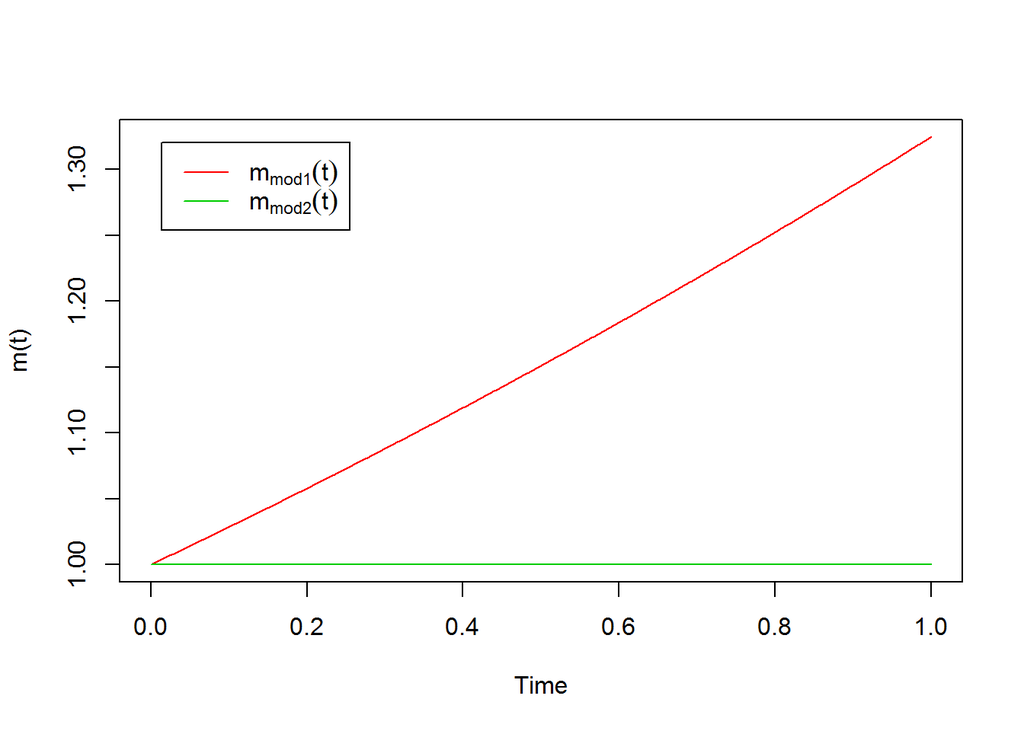

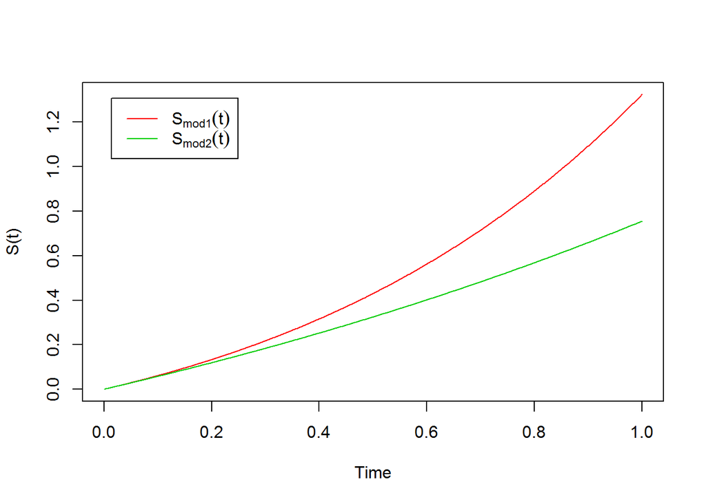

```r
R> plot(mem.mod1$sol.ode, mem.mod2$sol.ode,ylab = c("m(t)"),select="m", xlab = "Time",main="",col = 2:3,lty=1)
R> legend("topleft",c(expression(m[mod1](t),m[mod2](t))),inset = .05, col=2:3,lty=1)
R> plot(mem.mod1$sol.ode, mem.mod2$sol.ode,ylab = c("S(t)"),select="S", xlab = "Time",main="",col = 2:3,lty=1)
R> legend("topleft",c(expression(S[mod1](t),S[mod2](t))),inset = .05, col=2:3,lty=1)
```

## Two-dimensional SDEs

```r
R> fx <- expression(1/mu*(theta-x), x)
R> gx <- expression(sqrt(sigma),0)
R> start = c(m1=0,m2=0,S1=0,S2=0,C12=0)
R> t = seq(0,10,by=0.001)
R> mem.mod2d = MEM.sde(drift=fx,diffusion=gx,type="ito",solve = TRUE,parms = c(mu=1,sigma=0.5,theta=2), init = start, time = t)
R> mem.mod2d
```

```
Itô Sde 2D:
 | dX(t) = 1/1 * (2 - X(t)) * dt + sqrt(0.5) * dW1(t)
 | dY(t) = X(t) * dt + 0 * dW2(t)
 | t in [0,10].

Moment equations:
 | dm1(t)  = 2 - m1(t)
 | dm2(t)  = m1(t)
 | dS1(t)  = 0.5 - 2 * S1(t)
 | dS2(t)  = 2 * C12(t)
 | dC12(t) = S1(t) - C12(t)

Approximation of moment at time 10
  | m1(10)  =   1.9999 | S1(10)  =  0.25 | C12(10)  =  0.24998
  | m2(10)  =  18.0001 | S2(10)  =  4.25
```

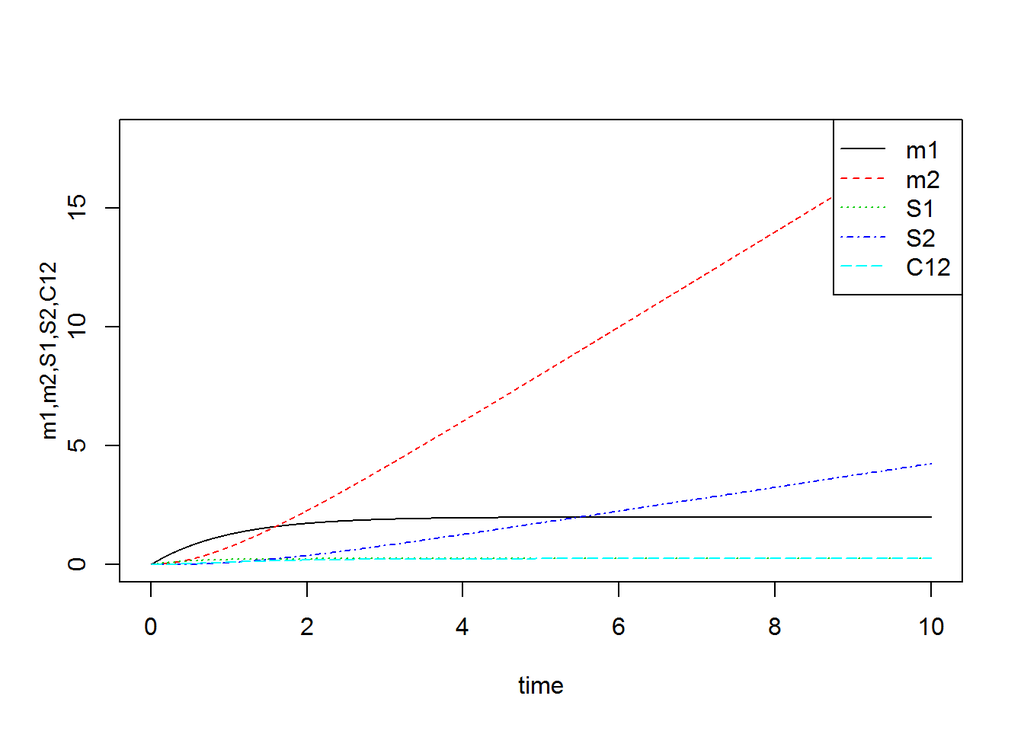

```r
R> matplot.0D(mem.mod2d$sol.ode,main="")
```

## Three-dimensional SDEs

```r
R> fx <- expression(mu*y,0,0)
R> gx <- expression(sigma*z,1,1)
R> start = c(m1=5,m2=0,m3=0,S1=0,S2=0,S3=0,C12=0,C13=0,C23=0)
R> t = seq(0,1,by=0.001)
R> mem.mod3d = MEM.sde(drift=fx,diffusion=gx,type="ito",solve = TRUE,parms = c(mu=0.5,sigma=0.25), init = start, time = t)
R> mem.mod3d
```

```
Itô Sde 3D:
 | dX(t) = 0.5 * Y(t) * dt + 0.25 * Z(t) * dW1(t)
 | dY(t) = 0 * dt + 1 * dW2(t)
 | dZ(t) = 0 * dt + 1 * dW3(t)
 | t in [0,1].

Moment equations:
 | dm1(t)  = 0.5 * m2(t)
 | dm2(t)  = 0
 | dm3(t)  = 0
 | dS1(t)  = (0.25 * m3(t))^2 + 0.0625 * S3(t) + C12(t)
 | dS2(t)  = 1
 | dS3(t)  = 1
 | dC12(t) = 0.25 * m3(t) + 0.5 * S2(t)
 | dC13(t) = 0.25 * m3(t) + 0.5 * C23(t)
 | dC23(t) = 1

Approximation of moment at time 1
   | m1(1)  =  5 | S1(1)  =  0.11458 | C12(1)  =  0.25
   | m2(1)  =  0 | S2(1)  =  1.00000 | C13(1)  =  0.25
   | m3(1)  =  0 | S3(1)  =  1.00000 | C23(1)  =  1.00
```

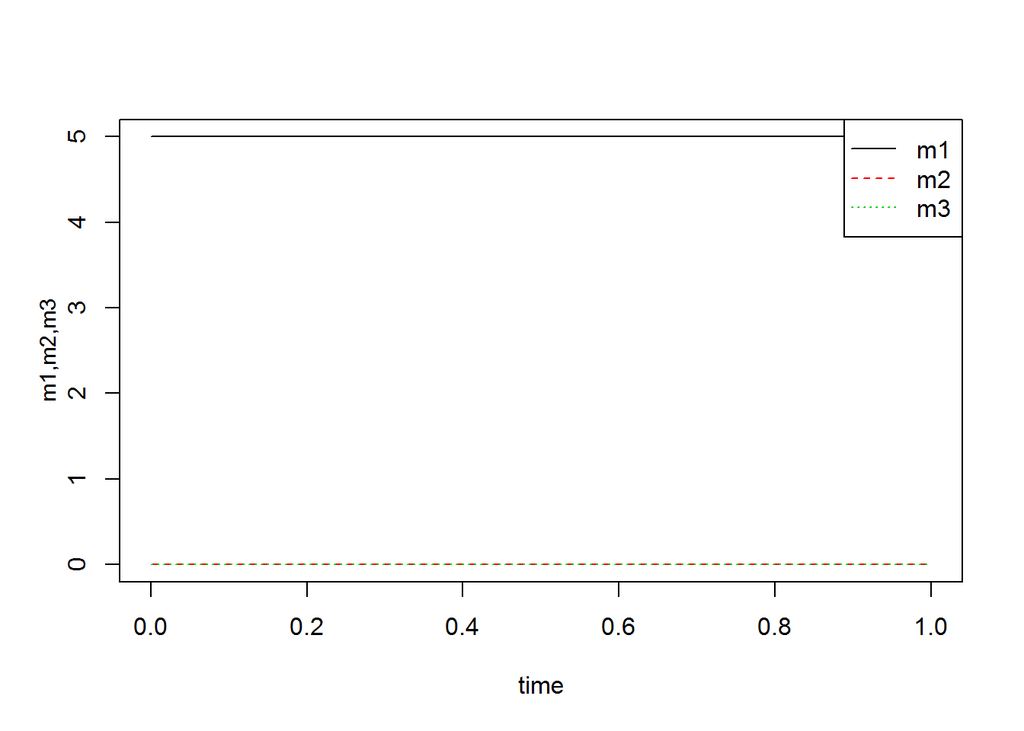

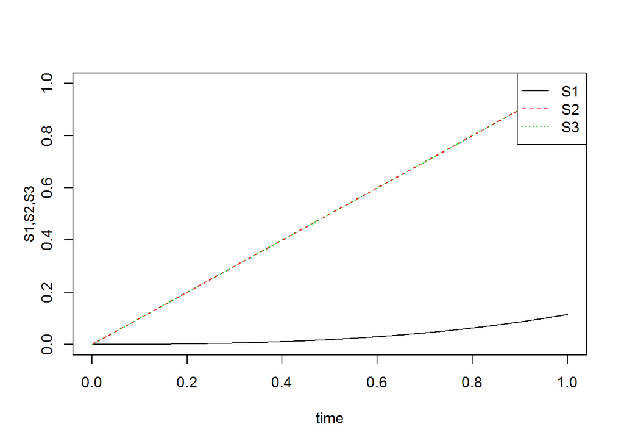

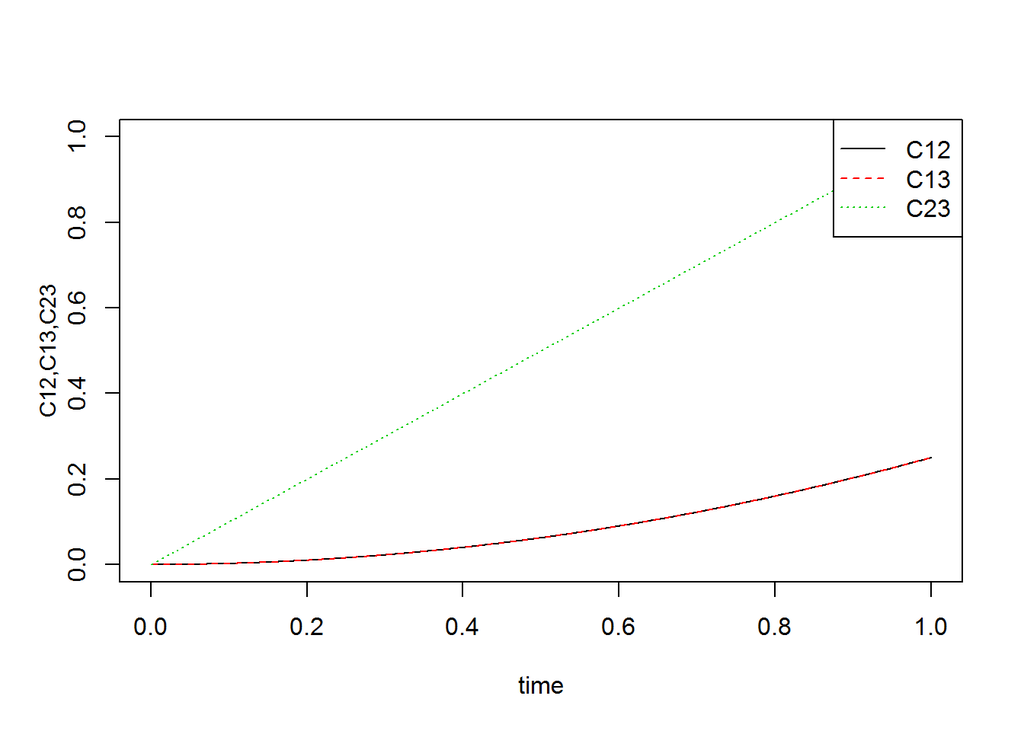

```r
R> matplot.0D(mem.mod3d$sol.ode,main="",select=c("m1","m2","m3"))
R> matplot.0D(mem.mod3d$sol.ode,main="",select=c("S1","S2","S3"))
R> matplot.0D(mem.mod3d$sol.ode,main="",select=c("C12","C13","C23"))
```

# Further reading

1. `snssdekd()` & `dsdekd()` & `rsdekd()`- Monte-Carlo Simulation and Analysis of Stochastic Differential Equations.
2. `bridgesdekd()` & `dsdekd()` & `rsdekd()` - Constructs and Analysis of Bridges Stochastic Differential Equations.
3. `fptsdekd()` & `dfptsdekd()` - Monte-Carlo Simulation and Kernel Density Estimation of First passage time.
4. `MCM.sde()` & `MEM.sde()` - Parallel Monte-Carlo and Moment Equations for SDEs.
5. `TEX.sde()` - Converting Sim.DiffProc Objects to LaTeX.
6. `fitsde()` - Parametric Estimation of 1-D Stochastic Differential Equation.

# References

1. Guidoum AC, Boukhetala K (2020). Performing Parallel Monte Carlo and Moment Equations Methods for Ito and Stratonovich Stochastic Differential Systems: R Package Sim.DiffProc. Accept Submission to Journal of Statistical Software.
2. Guidoum AC, Boukhetala K (2020). Sim.DiffProc: Simulation of Diffusion Processes. R package version 4.5, URL https://cran.r-project.org/package=Sim.DiffProc.
[^1]: Department of Probabilities & Statistics, Faculty of Mathematics, University of Science and Technology Houari Boumediene, BP 32 El-Alia, U.S.T.H.B, Algeria, E-mail (acguidoum@usthb.dz)
[^2]: Faculty of Mathematics, University of Science and Technology Houari Boumediene, BP 32 El-Alia, U.S.T.H.B, Algeria, E-mail (kboukhetala@usthb.dz)